# Data-Driven Approach To Predict Success Of Bank Telemarketing

Nisha Selvarajan

10/24/2020

### Objectives

*Data-Driven Approach To Predict Success Of Bank Telemarketing*

Nowadays, marketing spending in the banking industry is massive, meaning that it is essential for banks to optimize marketing strategies and improve effectiveness. Understanding customers’ need leads to more effective marketing plans, smarter product designs and greater customer satisfaction.The main objective of this project is to increase the effectiveness of the bank’s telemarketing campaign.This project will enable the bank to develop a more granular understanding of its customer base, predict customers’ response to its telemarketing campaign and establish a target customer profile for future marketing plans.

By analyzing customer features, such as demographics and transaction history, the bank will be able to predict customer saving behaviours and identify which type of customers is more likely to make term deposits. The bank can then focus its marketing efforts on those customers. This will not only allow the bank to secure deposits more effectively but also increase customer satisfaction by reducing undesirable advertisements for certain customers.

We are given the data of direct marketing campaigns (phone calls) of a Portuguese banking institution. The classification goal is to predict if the client will subscribe a term deposit (target variable y). The goal here is to model the probability of buying, as a function of the customer features.

### Data Description

- Data set which is utilized for this research has been taken from University of California, Irvine machine learning repository ( https://archive.ics.uci.edu/ml/datasets/Bank+Marketing?package=regsel&version=0.2) which is openly available for the public for research purpose. The dataset contains 41188 marketing campaigns observations with 20 input features. The details of 20 attributes are following.

| Names | Description |
| --- | --- |
| age | Numeric - Age of the client |
| job | Categorical - Type of Job |
| marital | Categorical - Marital Status of Client |
| education | Categorical - Education qualification of client |
| default | Categorical - Has credit in default? |
| housing | Categorical - Has housing loan? |
| loan | Categorical - Has personal loan? |
| contact | Categorical - Contact like cellular,telephone |
| month | Categorical - Last Contact Month of Year |
| day_of_week | Categorical - Last Contact Day of the Week |
| duration | Numerical - Last Contact Duration in Seconds |
| campaign | Numerical - No of contacts performed for Campaign |
| pdays | Numerical - No of days passed after previous campaign contact. |
| previous | Numerical - No of contacts performed before this campaign for this client |
| poutcome | Categorical - Outcome of the previous marketing campaign |
| emp.var.rate | Numerical - Employment Variation Rate - quarterly indicator |
| cons.price.idx | Numerical - Consumer price index - monthly indicator |
| cons.conf.idx | Numerical - Consumer confidence index - monthly indicator |
| euribor3m | Numerical- Euribor 3 month rate - daily indicator |
| nr.employed | Numerical- No of employees - quarterly indicator |
| y | Categorical- Has the client subscribed a term deposit? |

### Data Analysis

- Plot missing values of all the features in the dataset.

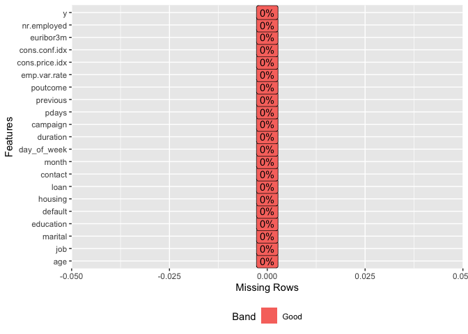

- Ploting histograms for numerical variables.

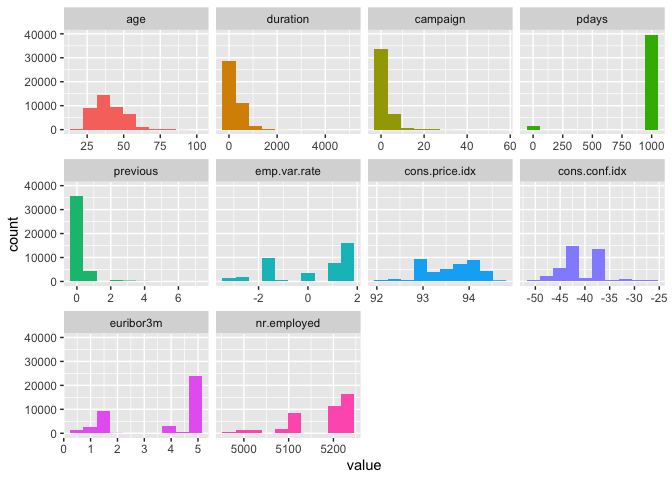

- Get metric table with many indicators for all numerical variables, automatically skipping the non-numerical variables.

```
##          variable         mean     std_dev variation_coef       p_01     p_05
## 1             age   40.0240604  10.4212500    0.260374632   23.00000   26.000
## 2        duration  258.2850102 259.2792488    1.003849386   11.00000   36.000
## 3        campaign    2.5675925   2.7700135    1.078836903    1.00000    1.000
## 4           pdays  962.4754540 186.9109073    0.194198103    3.00000  999.000
## 5        previous    0.1729630   0.4949011    2.861311858    0.00000    0.000
## 6    emp.var.rate    0.0818855   1.5709597   19.184834048   -3.40000   -2.900
## 7  cons.price.idx   93.5756644   0.5788400    0.006185797   92.20100   92.713
## 8   cons.conf.idx  -40.5026003   4.6281979   -0.114269154  -49.50000  -47.100
## 9       euribor3m    3.6212908   1.7344474    0.478958331    0.65848    0.797
## 10    nr.employed 5167.0359109  72.2515277    0.013983167 4963.60000 5017.500
##        p_25     p_50     p_75     p_95     p_99   skewness  kurtosis     iqr
## 1    32.000   38.000   47.000   58.000   71.000  0.7846682  3.791070  15.000
## 2   102.000  180.000  319.000  752.650 1271.130  3.2630224 23.245334 217.000
## 3     1.000    2.000    3.000    7.000   14.000  4.7623333 39.975160   2.000
```

[output cut: 18 more lines]

### Variable Importance & Crossplot to Deposit

- Plot variable importance with several metrics such as entropy (en), mutual information(mi), information gain (ig) and gain ratio (gr).

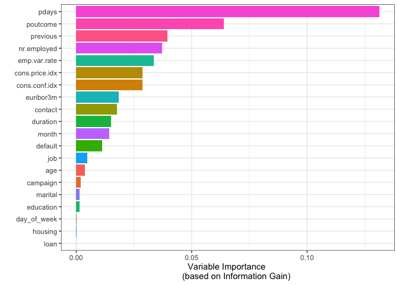

- Bivariate analysis crosss plot showing relationship of each and every variable with respect to target variable

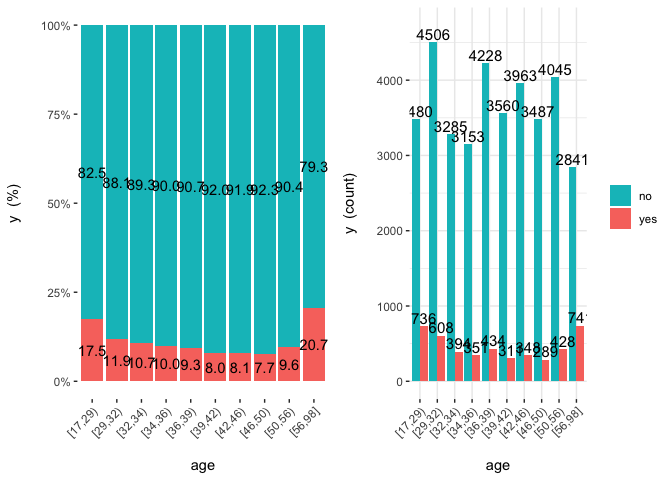

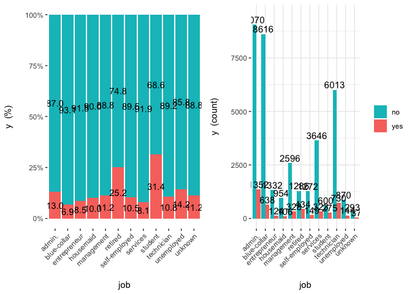

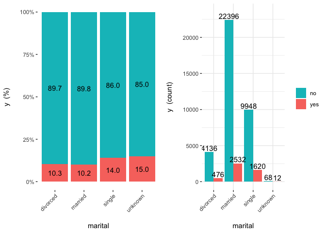

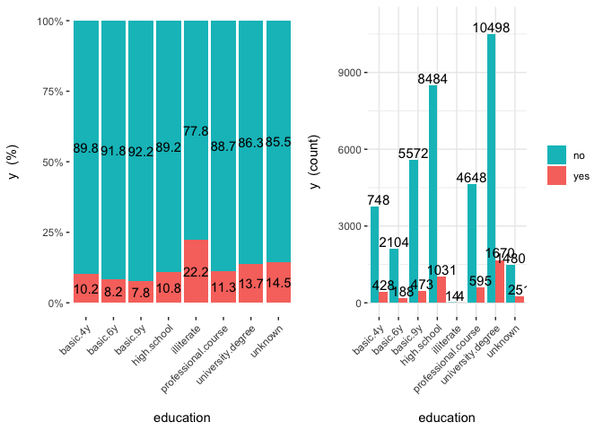

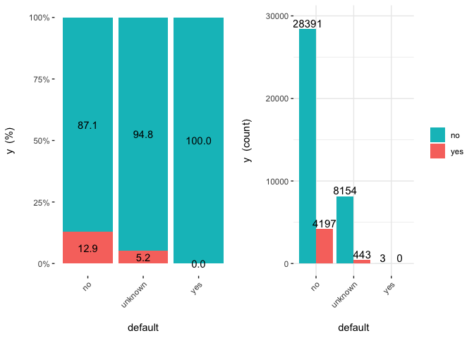

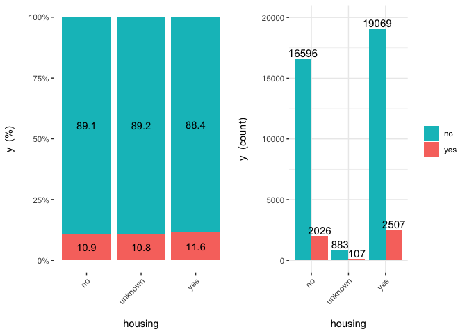

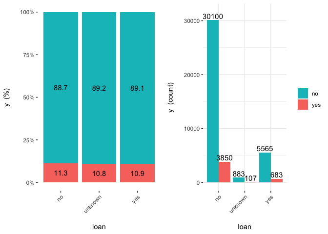

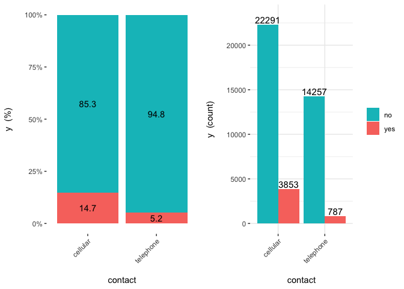

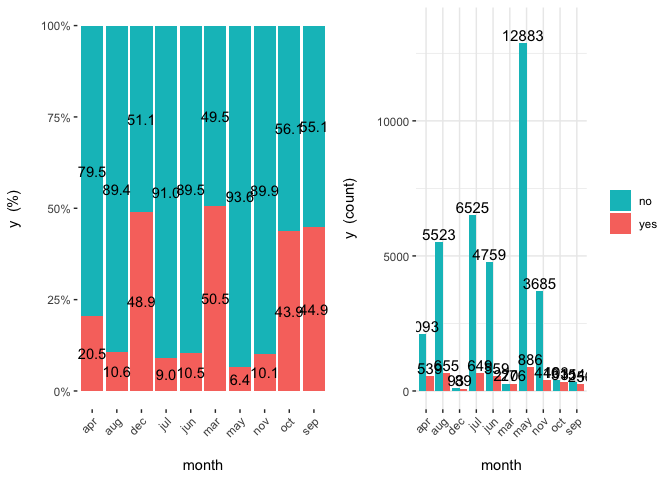

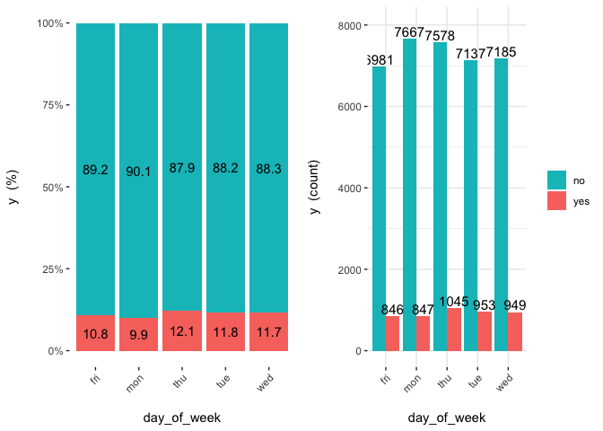

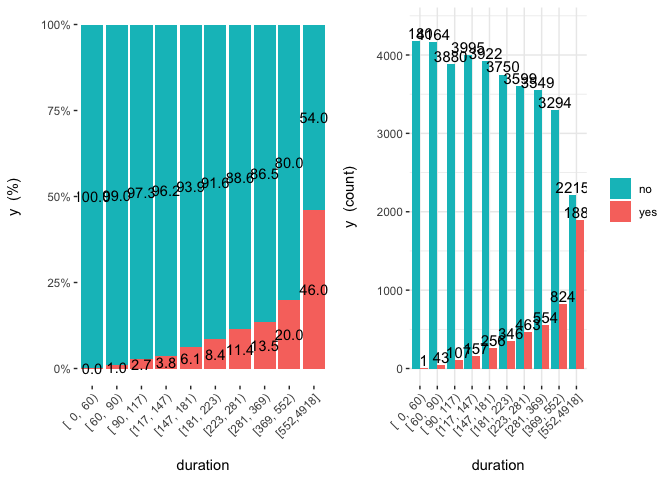

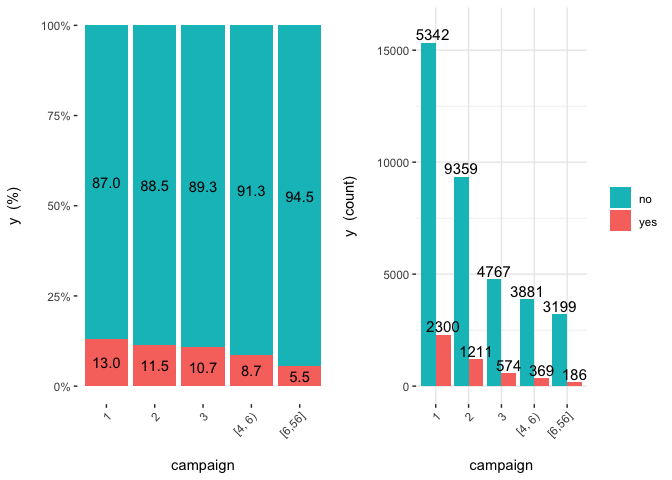

[8 more figures not shown]

### Prepare Data for Classification

- Select variables relevant to customers:Based on the variable importance, we will use pdays, poutcome,previous, duration, cons.price.idx,cons.conf.idx,contact feature for further analysis.

[output not shown]

- Load the cleaned dataset: - Convert categorical variable to numerical variable.
- Data slicing:
  - Dataset is split into 80 percent of training data, 20 % of test set.
- TrainingParameters :
  - train() method is passed with repeated cross-validation resampling method for 10 number of resampling iterations repeated for 3 times.

### Machine Learning: Classification using Neural Networks

- Model Training
  - We can us neuralnet() to train a NN model. Also, the train() function from caret can help us tune parameters. We can plot the result to see which set of parameters is fit our data the best.
  - nnnet package by defualt uses the Logisitc Activation function.
  - Data Pre-Processing With Caret: The scale transform calculates the standard deviation for an attribute and divides each value by that standard deviation.
  - The center transform calculates the mean for an attribute and subtracts it from each value.
  - Combining the scale and center transforms will standardize your data.
  - Attributes will have a mean value of 0 and a standard deviation of 1.
  - Training transforms can prepared and applied automatically during model evaluation.
  - Transforms applied during training are prepared using the preProcess() and passed to the train() function via the preProcess argument.
  - Backpropagation algorithm is a supervised learning method for multilayer feed-forward networks from the field of Artificial Neural Networks.
  - The principle of the backpropagation approach is to model a given function by modifying internal weightings of input signals to produce an expected output signal. The system is trained using a supervised learning method, where the error between the system’s output and a known expected output is presented to the system and used to modify its internal state.
  - We use Backpropagation as algorithm in neural network package.

```r
nnetGrid <-  expand.grid(size = seq(from = 1, to = 5, by = 1)
                         ,decay = seq(from = 0.1, to = 0.2, by = 0.1)
                         )
nn_model <- train(Term_Deposit ~ ., subTrain,
                  method = "nnet",  algorithm = 'backprop',
                  trControl= TrainingParameters,
                  preProcess=c("scale","center"),
                  na.action = na.omit,
                  #metric = "ROC",
                  tuneGrid = nnetGrid,
                  trace=FALSE,
                  verbose=FALSE)
```

- Based on the caret neural network model, train sets hidden layer.caret neural network picks the best neural network based on size, decay.We can visualize accuracy for different hidden layers below:

```
##    size decay  Accuracy     Kappa  AccuracySD    KappaSD
## 1     1   0.1 0.9040427 0.4358269 0.002567681 0.01507662
## 2     1   0.2 0.9039820 0.4367773 0.002584615 0.01548641
## 3     2   0.1 0.9051791 0.4418804 0.002210548 0.02086579
## 4     2   0.2 0.9052600 0.4422005 0.002728089 0.01602451
## 5     3   0.1 0.9055163 0.4370649 0.003408263 0.04122454
## 6     3   0.2 0.9060626 0.4388124 0.003642564 0.04049697
## 7     4   0.1 0.9074754 0.4514426 0.003252861 0.02746812
## 8     4   0.2 0.9075294 0.4470578 0.002480409 0.03099499
## 9     5   0.1 0.9078261 0.4603130 0.002673938 0.02354327
## 10    5   0.2 0.9077991 0.4425523 0.004547698 0.07854141
```

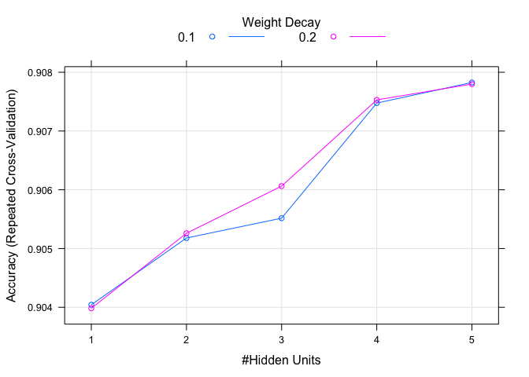

```
##
## prediction  no yes
##        no  284  25
##        yes   8  16
```

- Confusion matrix & Accuracy of Neural Network model:

```
## [1] 0.9009009
```

```
## Confusion Matrix and Statistics
##
##           Reference
## Prediction  no yes
##        no  284  25
##        yes   8  16
##
##                Accuracy : 0.9009
##                  95% CI : (0.8636, 0.9308)
##     No Information Rate : 0.8769
##     P-Value [Acc > NIR] : 0.103011
##
##                   Kappa : 0.4415
##
##  Mcnemar's Test P-Value : 0.005349
##
##             Sensitivity : 0.9726
##             Specificity : 0.3902
##          Pos Pred Value : 0.9191
##          Neg Pred Value : 0.6667
##              Prevalence : 0.8769
##          Detection Rate : 0.8529
##    Detection Prevalence : 0.9279
##       Balanced Accuracy : 0.6814
##
##        'Positive' Class : no
##
```

- Confusion matrix & Accuracy of Neural Network model:
  - Plotting nnet variable importance

```
## nnet variable importance
##
##                                    Overall
## ConsumerConfidenceIndex            100.000
## LastContactDuration                 67.780
## ContactCommunicationType            52.298
## NumberOfDaysPassedAfterLastContact  50.969
## ConsumerPriceIndex                  46.995
## PreviousMarketingOutCome             6.867
## NoOfContactsPerformed                0.000
```

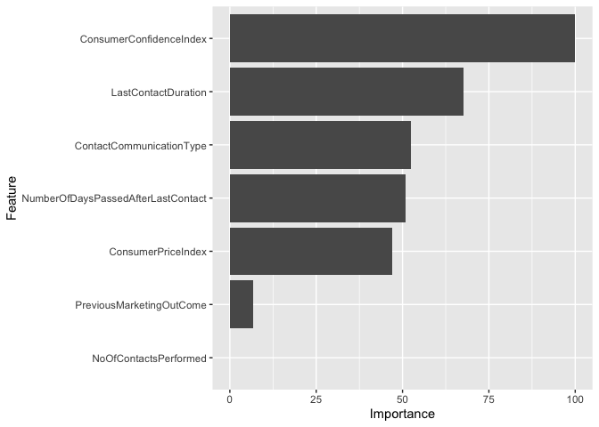

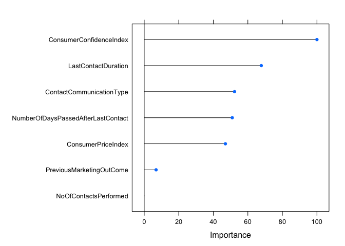

- Graphical Representation of our Neural Network

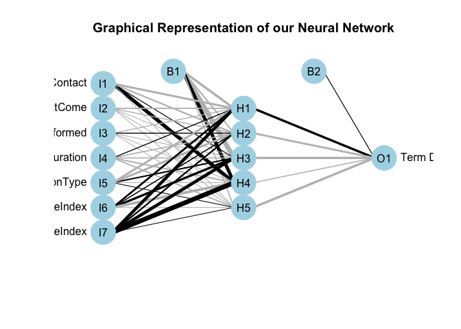

### Machine Learning: Classification using SVM

- SVM is another classification method that can be used to predict if a client falls into either ‘yes’ or ‘no’ class.
  - The linear, polynomial and RBF or Gaussian kernel in SVM are simply different in case of making the hyperplane decision boundary between the classes.
  - The kernel functions are used to map the original dataset (linear/nonlinear ) into a higher dimensional space with view to making it linear dataset.
  - Usually linear and polynomial kernels are less time consuming and provides less accuracy than the rbf or Gaussian kernels.
  - The k cross validation is used to divide the training set into k distinct subsets. Then every subset is used for training and others k-1 are used for validation in the entire trainging phase. This is done for the better training of the classification task.Overall, if you are unsure which kernel method would be best, a good practice is use of something like 10-fold cross-validation for each training set and then pick the best algorithm.

### SVM Classifier using Linear Kernel

```r
trctrl <- trainControl(method = "repeatedcv", number = 10, repeats = 2)
set.seed(323)
grid <- expand.grid(C = c( 0.25, 0.5, 1))
svm_Linear_Grid <- train(Term_Deposit ~ ., data = subTrainSVM, method = "svmLinear", trControl=trctrl, preProcess = c("center", "scale"),
                         tuneGrid = grid,
                         tuneLength = 10)
svm_Linear_Grid
```

```
## Support Vector Machines with Linear Kernel
##
## 9888 samples
##    7 predictor
##    2 classes: 'no', 'yes'
##
## Pre-processing: centered (7), scaled (7)
## Resampling: Cross-Validated (10 fold, repeated 2 times)
## Summary of sample sizes: 8898, 8900, 8899, 8900, 8899, 8899, ...
## Resampling results across tuning parameters:
##
##   C     Accuracy   Kappa
##   0.25  0.8997786  0.2837249
##   0.50  0.8997786  0.2837249
##   1.00  0.8997786  0.2837249
##
## Accuracy was used to select the optimal model using the largest value.
## The final value used for the model was C = 0.25.
```

- The above model is showing that our classifier is giving best accuracy on C = 0.25 Let’s try to make predictions using this model for our test set and check its accuracy.

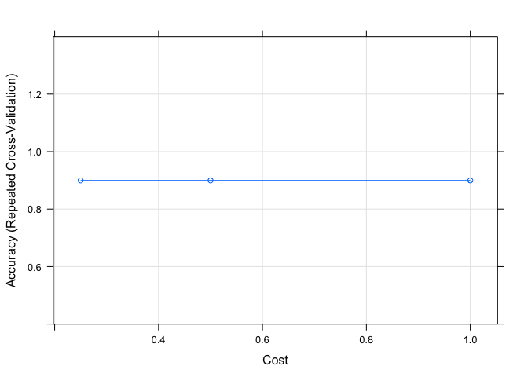

```
## [1] 0.9166667
```

- Final prediction accuracy on the test set is 0.9166667.

### SVM Classifier using Non-Linear Kernel

- Now, we will try to build a model using Non-Linear Kernel like Radial Basis Function. For using RBF kernel, we just need to change our train() method’s “method” parameter to “svmRadial”. In Radial kernel, it needs to select proper value of Cost “C” parameter and “sigma” parameter.

```r
set.seed(323)
grid_radial <- expand.grid(sigma = c(0.25, 0.5,0.9),
 C = c(0.25, 0.5,1))
svm_Radial <- train(Term_Deposit ~ ., data = subTrainSVM, method = "svmRadial",
trControl=trctrl,
preProcess = c("center", "scale"),tuneGrid = grid_radial,
tuneLength = 10)

svm_Radial
```

```
## Support Vector Machines with Radial Basis Function Kernel
##
## 9888 samples
##    7 predictor
##    2 classes: 'no', 'yes'
##
## Pre-processing: centered (7), scaled (7)
## Resampling: Cross-Validated (10 fold, repeated 2 times)
## Summary of sample sizes: 8898, 8900, 8899, 8900, 8899, 8899, ...
## Resampling results across tuning parameters:
##
##   sigma  C     Accuracy   Kappa
##   0.25   0.25  0.9131796  0.4235344
##   0.25   0.50  0.9128756  0.4232314
##   0.25   1.00  0.9153028  0.4430922
##   0.50   0.25  0.9163140  0.4454370
##   0.50   0.50  0.9198031  0.4851975
##   0.50   1.00  0.9230389  0.5121697
##   0.90   0.25  0.9220279  0.4926883
##   0.90   0.50  0.9236464  0.5192152
##   0.90   1.00  0.9271349  0.5520005
##
## Accuracy was used to select the optimal model using the largest value.
## The final values used for the model were sigma = 0.9 and C = 1.
```

- SVM-RBF kernel calculates variations and will present us best values of sigma & C. Based on the output best values of sigma= 0.9 & C=1 Let’s check our trained models’ accuracy on the test set.

```
## [1] 0.8333333
```

- Final prediction accuracy on the test set is 0.8333333

### Comparision between SVM models

- Comparision between SVM Linear and Radial Models.

```
##
## Call:
## summary.resamples(object = algo_results)
##
## Models: SVM_RADIAL, SVM_LINEAR
## Number of resamples: 20
##
## Accuracy
##                 Min.   1st Qu.    Median      Mean   3rd Qu.      Max. NA's
## SVM_RADIAL 0.9130435 0.9221436 0.9281750 0.9271349 0.9324393 0.9372470    0
## SVM_LINEAR 0.8917004 0.8935794 0.8993427 0.8997786 0.9035121 0.9129555    0
##
## Kappa
##                 Min.   1st Qu.    Median      Mean   3rd Qu.      Max. NA's
## SVM_RADIAL 0.4714582 0.5264890 0.5552111 0.5520005 0.5850553 0.6261048    0
## SVM_LINEAR 0.1811203 0.2504363 0.2763777 0.2837249 0.3243298 0.3717218    0
```

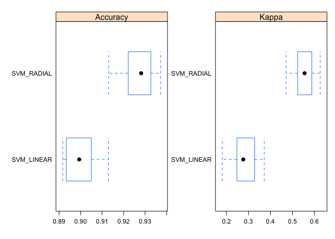

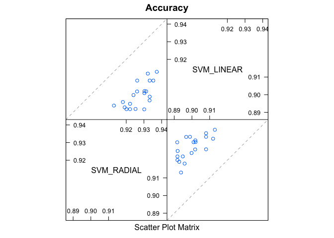